# Chicago Crime Data Analysis

Student ID: 201081646

November 3, 2018

# Introduction

This report is the first assessment for the **MATH5741M Statistical Theory and Methods** module. Its objective is to summarise statistically a dataset sample of crimes in the city of Chicago and answer the following research questions:

- What time of day do most types of crime in Chicago occur?
- In which locations are specific types of crime more likely to happen?
- Which districts of the city are potentially more dangerous per type of crime?

# Data and methods

The dataset analysed is a sample of the [original data of crimes extracted from the Chicago Police Department](https://data.cityofchicago.org/Public-Safety/Crimes-2001-to-present/ijzp-q8t2) which content the crimes that occurred in the city of Chicago from 2001 to present.

For the analysis, first, we prepare the data creating, transforming and simplifying variables, as well as cleaning the dataset keeping the variables we are interested in. Secondly, we make a general univariable analysis of the data set, and then, with a multianalysys based on heatmaps we answer our questions. Finally, we sumarise the findings.

This report has been done with `Rmarkdown`, although due to space limitations only the `R` code cells that have been considered most significant are shown. To see the complete code see https://github.com/eugenividal/Chicago-Crime-Data-Analysis.

# Results

## Data preparation

First, we load the data into the `R` environment.

```r
# read csv in R
dd=read.csv("http://www1.maths.leeds.ac.uk/~charles/math5741/crime.csv",header=T)
```

Second, we create new variables (`count`, `hour`) based on the existing ones, and give them the right format for later explotation.

Third, we simplify the variables `Primary.Type` and `Location.Description` grouping their categories and call them `Type_grouped` and `Location_grouped` respectivelly.

Next, we keep only those variables which will help us to answer our questions. So, we drop all the variable we do not need.

```r
# drop all variables we are not interested in
dd <- dd[, -c(1:8, 10:11, 13:18)]
```

Then, we clean the dataset of missing values.

```r
# remove NAs
dd <- dd[complete.cases(dd),]
```

Finally, the data is ready for the explotation.

```r
head(dd)
```

```
##   Arrest District count hour   Month_Yr Type_grouped Location_grouped
## 1   true       19     1   00 2013-07-01       Batery           Street
## 2   true       19     1   01 2013-07-01       Others           Street
## 3  false        2     1   21 2013-07-01      Assault        Apartment
## 4   true        9     1   02 2013-07-01    Narcotics           Street
## 5  false        3     1   17 2013-07-01        Theft           Street
## 6   true        9     1   01 2013-07-01       Batery        Apartment
```

## Data exploration

### General analysis

#### Crime evolution

The number of crimes in Chicago has decrease dramatically per year from 2001 to present.

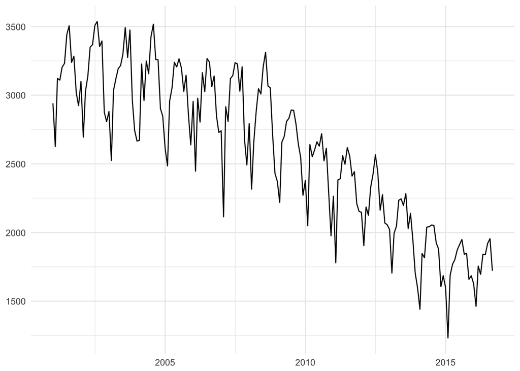

Crimes evolution

Except for the deceptive practice, all the crimes have decresead in more or less grade.

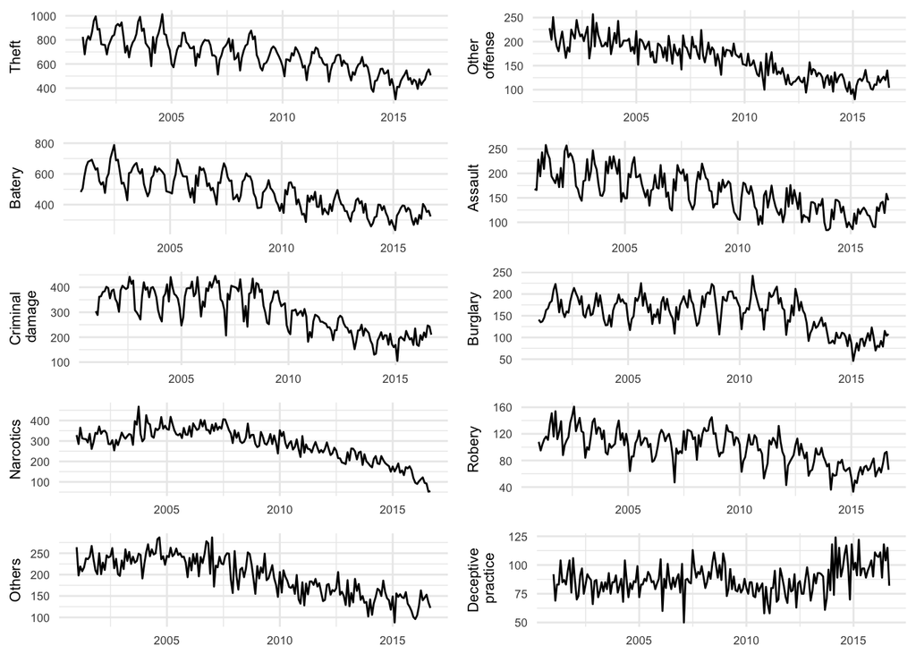

Evolution per type of crime

#### Crime per hour

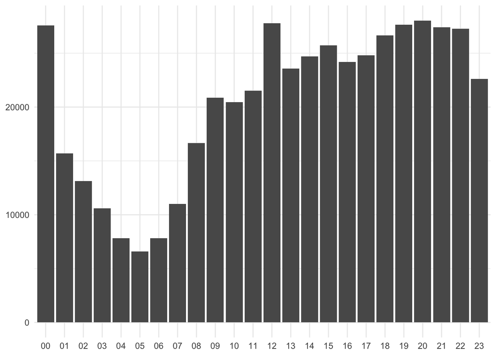

Crimes per hour

#### Type of crimes

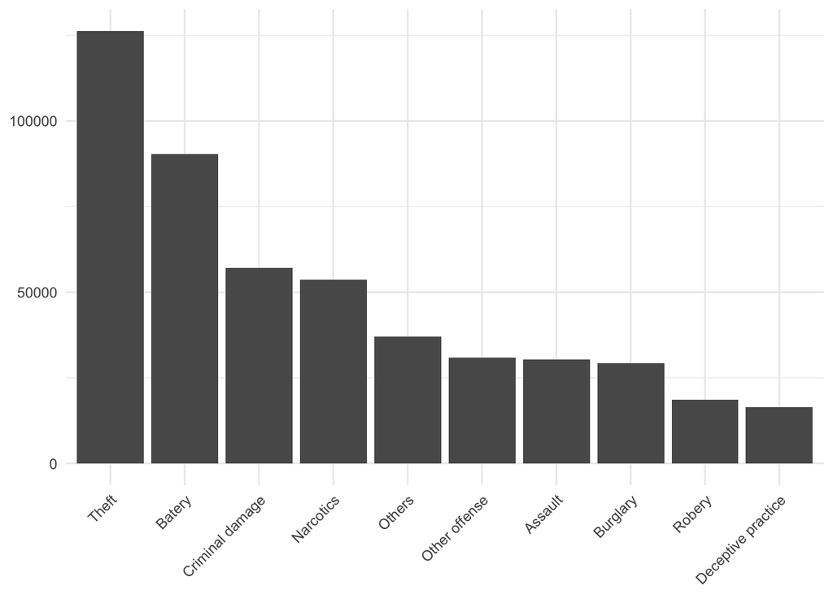

Crimes per type

#### Location of crimes

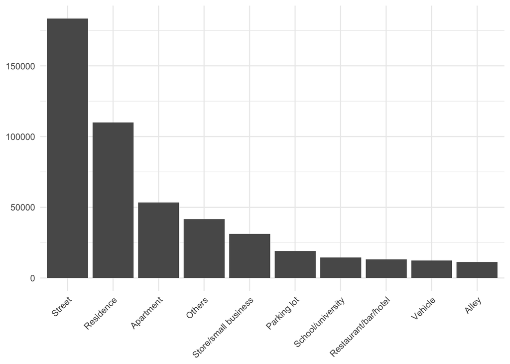

Crimes per location

### Answers to our questions

The multiple analysis focuses on type of crime crossed with hour, location and district.

#### What time of day do most types of crime in Chicago occur?

Are some types of crimes more likely to happen in specific time of the day?

The most dangerous hours per Thefth are 00 and 12.

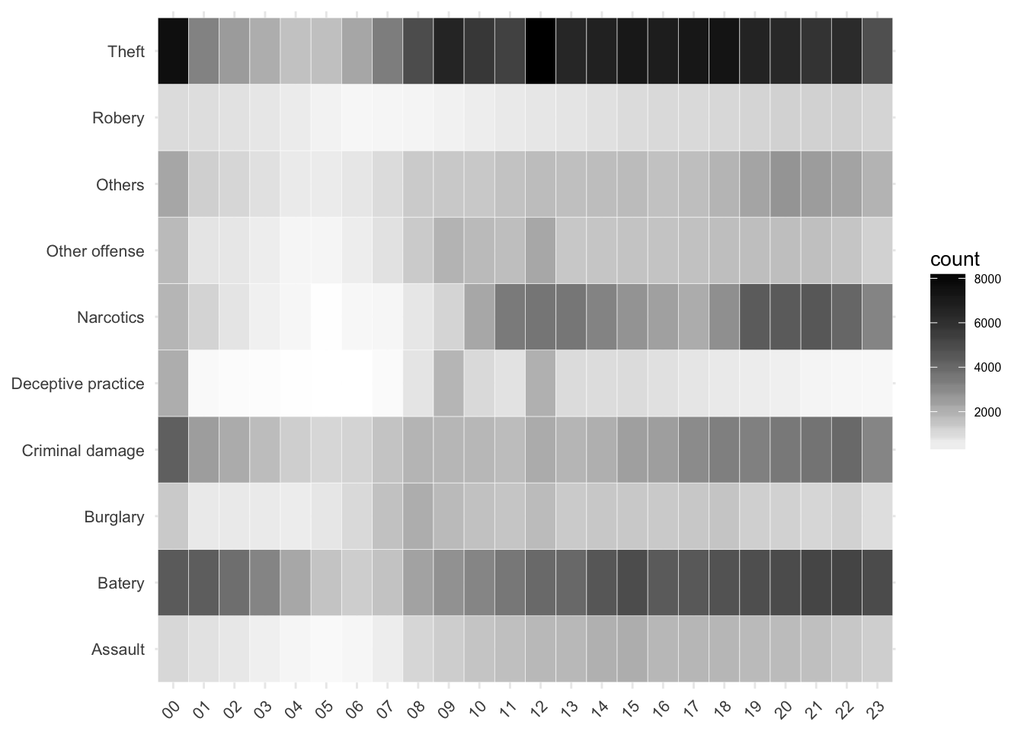

Type of crime vs hour

#### In which locations are specific types of crime more likely to happen?

Are some types of crimes more likely to happen in specific locations?

Street is particularly important for Theft.

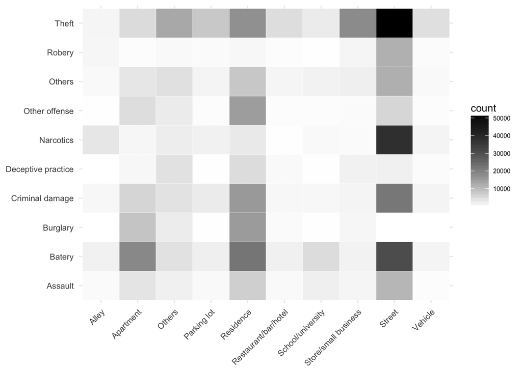

Type of crime vs location

#### Which districts of the city are potentially more dangerous per type of crime?

Are some types of crimes more likely to happen in specific distrits?

Narcotics in district 11 is crealy a problem.

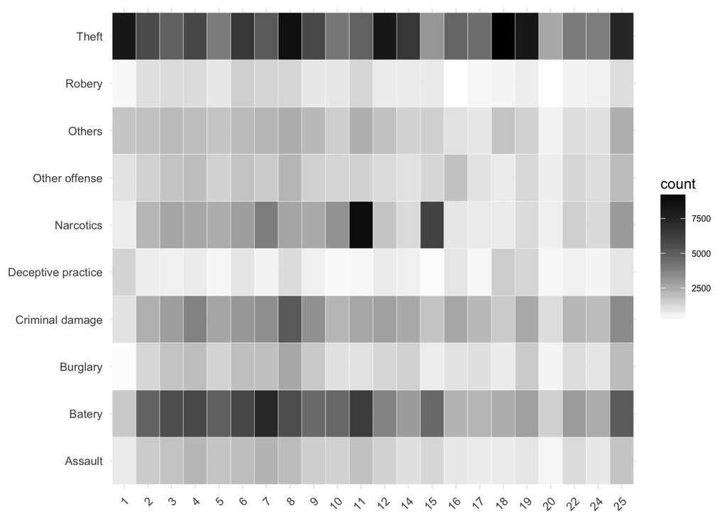

Type of crime vs district